# About me

Hi! My name is Steph, a 2nd year MHS student in Infectious Disease Epidemiology. I’m interested in the impact infectious conditions have on reproductive and perinatal outcomes, and hope to aid in the translation of epidemiologic work to local and state maternal and child health policies. I am familiar with R and Python from my time in mood disorder research, but as you can tell with this very simple site, I still have lots to learn :) I’m looking forward to expanding my skills in this course.

# Five Interesting Facts About Me

1. I’m from Chicago and lived in Salt Lake City, UT post graduating from the University of Illinois at Chicago
2. I have a rescue named Bowie who is sadly waiting for me in Chicago with my family as I finish out my program (I take way too many pictures of him)
3. I love being in the mountains, desert, lakes… really anywhere outside! I’m also getting back into bouldering
4. I could usually be found in museums or concerts quite often pre-COVID
5. I’m patiently waiting to begin international traveling again. My favorite trips thus far include a motorcycle roadtrip through Honduras and getting stranded in a snowstorm in Iceland

## Speaking of taking too many pictures of my dog…

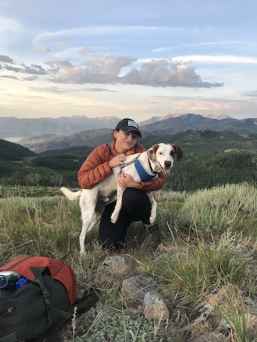

Me and Bowie in Park City, UT

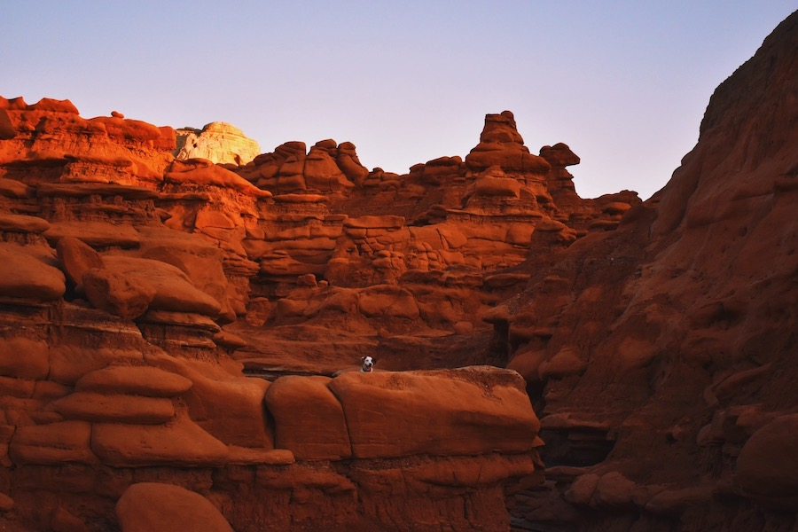

Bowie amongst some hoodoos

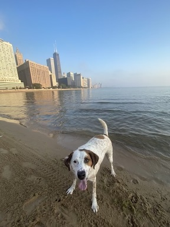

Bowie enjoying his neighborhood beach, Chicago

### A few of my favorite sites

I love watching old concert videos, which has been clutch in the COVID-era [link](https://www.youtube.com/watch?v=53dikqNZLgA)

To keep up with maternal and child health topics [link](https://www.who.int/health-topics/maternal-health#tab=tab_1)